# Rによる機械学習 Ridge・Lasso回帰

Cho（ztempest0218@gmail.com）

Last Updated: 2026-10-12

**データのダウンロード**

保存先は、講義のプロジェクトフォルダを基準にする。

- **FIFAデータ**：fifa20-abilities.csvを `data/fifa/` に保存する。
- **住宅データ**：train.csv、test.csv、data_description.txtを `data/house-prices/` に保存する。前回のファイルをそのまま使える。

```r
rm(list = ls())

# 適宜、wdを設定すること

# パッケージの読み込み
library(dplyr)
library(showtext)

# 日本語フォントの設定
font_add_google("Noto Sans JP", "notojp")
showtext_auto()
```

**今回の内容**

- FIFAデータで考える多重共線性と高次元モデル
- AIC・BICと正則化、Ridge・Lasso回帰
- 変数処理と交差検証
- Rによる住宅価格の予測

入門編の第11回では、多重共線性によって回帰係数を解釈しにくくなることを学んだ。機械学習の第1回では過学習、第2回では特徴量エンジニアリングと予測性能の評価を扱った。今回は、**説明変数を多く使いたいときに、どのように回帰モデルを学習させるか**を考える。

# 1 多重共線性と高次元モデル

## 1.1 復習：サッカー選手の能力と多重共線性

入門編の[第11回「回帰分析の基礎」](https://ztempest0218.github.io/R-Programming/011-regression-analysis.html)で取り上げた、サッカー選手の例から考えよう。選手の年俸を、ドリブル能力・加速力・シュート精度から予測するとする。

$$\hat y_i=\hat\beta_0+\hat\beta_1x_{i1}
+\hat\beta_2x_{i2}+\hat\beta_3x_{i3}$$

$y_i$ は選手 $i$ の年俸、$x_{i1}$ はドリブル能力、$x_{i2}$ は加速力、$x_{i3}$ はシュート精度を表す。$\hat y_i$ は年俸の予測値であり、$\hat\beta_j$ は推定した回帰係数である。

例えば、メッシを思い浮かべてほしい。ドリブルがうまいだけでなく、素早く動けて、シュートもうまい。このように、優れた選手は、いくつもの能力が高いことがある。

では、年俸が高いのは、ドリブルがうまいからだろうか。それとも、加速力が高いからだろうか。シュートがうまいからだろうか。これらの能力の点数がいつも一緒に上がったり下がったりしていると、データがあっても、どの能力がどれだけ年俸と関係しているのかを、分けて調べることが難しくなる。このように、説明変数同士が強く関連していて、それぞれの係数を決めにくくなる問題を、**多重共線性**という。

入門編で使った「FIFA 20」の選手データからGKを除き、6つの能力値の相関を確認しよう。

| 能力 | データの列名 |
| --- | --- |
| ドリブル | `skill_dribbling` |
| 加速力 | `movement_acceleration` |
| シュート精度 | `attacking_finishing` |
| 最高速度 | `movement_sprint_speed` |
| ボールコントロール | `skill_ball_control` |
| ショートパス | `attacking_short_passing` |

```r
fifa <- read.csv("data/fifa/fifa20-abilities.csv")

# GKを除く
outfield <- fifa %>%
  filter(player_positions != "GK")

# 6つの能力を選び、列名を日本語にする
abilities <- outfield %>%
  select(
    ドリブル = skill_dribbling,
    加速力 = movement_acceleration,
    シュート精度 = attacking_finishing,
    最高速度 = movement_sprint_speed,
    ボール制御 = skill_ball_control,
    ショートパス = attacking_short_passing
  )

# 選手の人数を確認する
nrow(abilities)
```

```
## [1] 16422
```

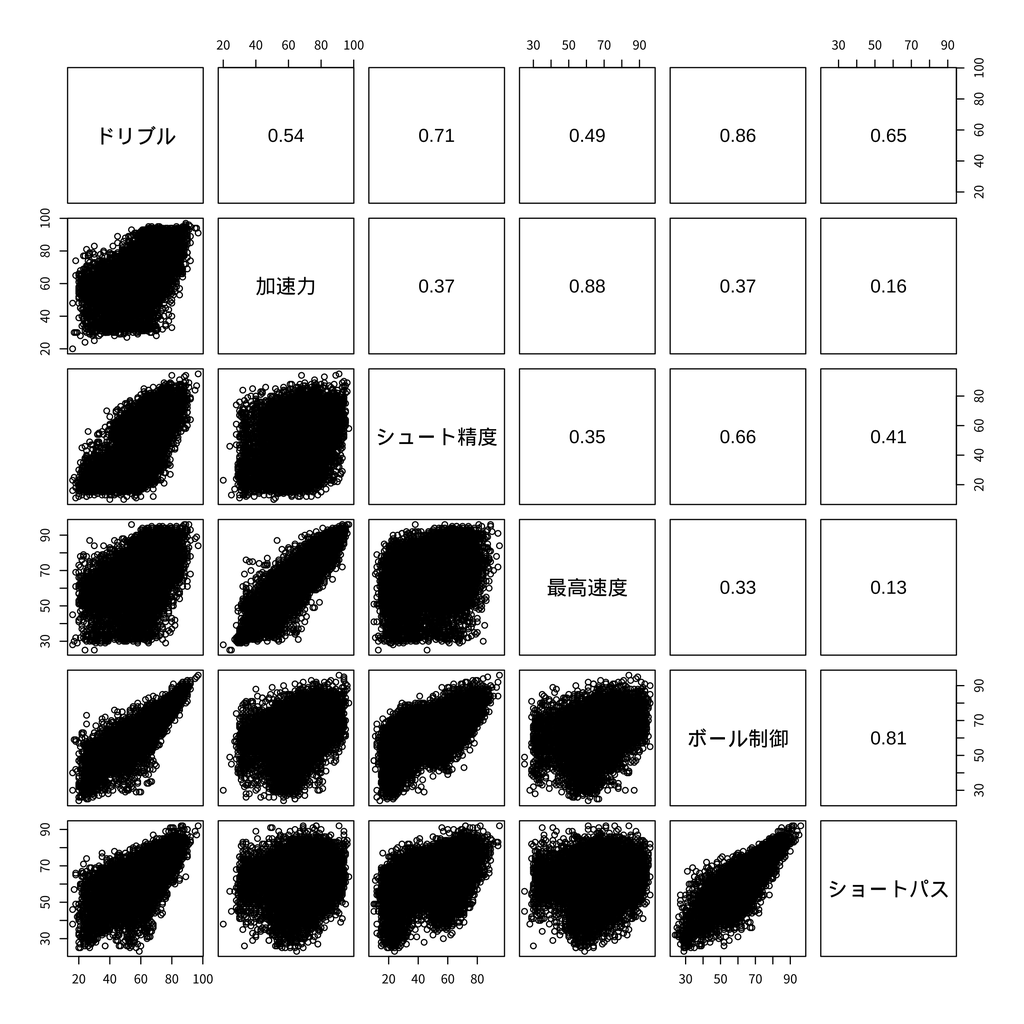

```r
# 上三角に相関係数を表示する関数
panel_cor <- function(x, y, ...)
  text(mean(range(x)), mean(range(y)), round(cor(x, y), 2), cex = 1.5)

# 相関図行列を描く
pairs(abilities, family = "notojp", upper.panel = panel_cor)
```

加速力と最高速度の相関係数は 0.88、ドリブルとボール制御は 0.86、ボール制御とショートパスは 0.81 である。ドリブルとシュート精度も 0.71 と高く、これらの能力はよく似た動きをしている。

## 1.2 説明変数が多くなるとどうなる

### 次元の呪い

サイコロを考える。各サイコロの出た目は互いに独立である。組み合わせは、1個なら6通り、2個なら36通り、3個なら216通りと、一つ増やすたびに6倍になる。

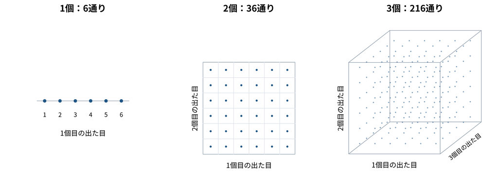

サイコロが1個、2個、3個、4個の場合について、それぞれ216回振り、出た目を記録する。どの場合も、1回分の結果を1件とし、データは216件になる。

| サイコロの数 | 出た目の組み合わせ | 1組み合わせあたりの平均件数 |
| --- | --- | --- |
| 1個（1次元） | 6 | 36回 |
| 2個（2次元） | 36 | 6回 |
| 3個（3次元） | 216 | 1回 |
| 4個（4次元） | 1,296 | 1回未満 |

4個なら、組み合わせは $6^4=1{,}296$ 通りになる。しかし、216回しか試さなければ、少なくとも1,080通りは一度も観測できない。

これが**次元の呪い**の一例である。変数が増えるほど、組み合わせが増え、それぞれに使えるデータが少なくなる。

トップ選手の年俸を予測する場面で考えよう。ドリブルが同じくらいうまい選手は多くても、加速力も同じくらいの選手に絞ると5人、さらにシュート精度も同じくらいとなると1人しか残らないとする。この場合、能力が似た選手と比較するためのデータが足りず、年俸を推定しにくくなる。

観測数を $n$、説明変数の数を $p$ とする。観測数に対して説明変数が多いデータを**高次元データ**と呼ぶ。少ない観測から大量の係数を決めるため、変数の選択や係数の調整を自動で行う方法が必要になる。

#### 行が多い・列が少ない

行 × 列：*n* × *p* = 24 × 4

少数の変数を、多くの観測で調べる

#### 行が少ない・列が多い

行 × 列：*n* × *p* = 4 × 24

多くの係数を、少ない観測から決める

## 1.3 なぜOLSがダメなのか

重回帰モデルは、次のように表される。

$$y_i=\beta_0+\beta_1x_{i1}+\beta_2x_{i2}+\cdots+\beta_px_{ip}+\varepsilon_i$$

$p$ は説明変数の数である。

「説明変数を増やせば、もっとよい回帰になる」とは限らない。OLSでは、$X$ を増やすと学習データへの当てはまりはよくなるか、同じままである。（同じ学習データで説明変数を増やしても、決定係数 $R^2$ は下がらない。）しかし、多重共線性が強いと、データの少しの違いで係数の大きさや符号が変わることがある。

特に、サンプル数が少なく変数が多いと、推定が不安定になり、過学習も起こりやすい。切片を含むOLSでは、$p\geq n$ になると係数を一つに決められない。変数を増やすだけでは、安定した推定や正確な予測は保証されない。

実際のデータでは、次のような例がある。

| 問題 | データ | 説明変数 | 特徴 |
| --- | --- | --- | --- |
| 多重共線性 | サッカー | 加速力・最高速度 | 似た情報を持つ |
| 多重共線性 | 住宅 | 面積・部屋数 | 一緒に増えやすい |
| 高次元 | 遺伝子発現 | 各遺伝子の測定値 | 少ない検体、多数の測定項目 |
| 高次元 | 文章 | 単語の出現回数 | 文書数より単語の種類が多い |

例えば、白血病の研究で使われるALLデータには、128検体について12,625個の測定項目が記録されている。つまり、観測数は $n=128$、説明変数の数は $p=12{,}625$ であり、観測数より変数がはるかに多い。興味がある人は、RのALLパッケージからデータを読み込み、自分で分析してみてほしい。授業では詳しく扱わないが、行と列のある表に整理できるため、基本的な分析操作はこれまで学んだ方法で進められる。医学の専門知識がなくても、遺伝子の発現量を $X$、白血病の種類（B細胞型・T細胞型）を $y$ として、データから種類を予測する分類モデルを作ってみることができる。

どの変数を残すかを人が一つずつ決めると、主観に左右されやすい。機械学習の**教師あり学習**では、説明変数 $X$ から $\hat{y}=f(X)$ と予測し、通常、一つひとつの係数の解釈よりも、新しいデータの $y$ を正確に予測できるかを重視する。そこで今回は、**変数の選択や係数の調整を自動で行う方法**としてRidgeとLassoを学び、予測性能を比較してモデルを選ぶ。

# 2 正則化とRidge・Lasso回帰

## 2.1 赤池のAICと正則化の考え方

統計数理研究所（ISM）の元所長、**赤池弘次**が提案した**AIC（赤池情報量規準）**は、モデルの当てはまりだけでなく、複雑さも考慮してモデルを選ぶための基準である。BICも、当てはまりと複雑さの両方を評価する。AIC・BICは時系列モデルでもよく使われ、過去の値を何期前まで使うかという**ラグ次数の選択**にも利用される。

考え方は、学習データによく合うだけでなく、**複雑すぎるモデルにはペナルティを加える**というものである。変数を増やして当てはまりが改善しても、それに見合うだけの改善かを考える。

これから学ぶRidgeとLassoにも、モデルの複雑さを抑えるという共通の考え方がある。AICがパラメータ数にペナルティを加えてモデルを比較するのに対し、RidgeとLassoでは、係数を推定するときに、その大きさにペナルティを加える。これが今回扱う**正則化**である。

## 2.2 損失関数と係数のペナルティ

予測値が実際の値からどれだけ外れているかを数値で表すものを、**損失関数（loss function）**という。OLSは、予測誤差の二乗和を最小にする。ここでは、`glmnet` と同じく、残差平方和を $2n$ で割った損失関数を使う。

$$L(\boldsymbol\beta)=\frac{1}{2n}\sum_{i=1}^{n}(y_i-\hat y_i)^2$$

$\hat y_i$ はモデルの予測値を表す。ここでは、切片も含めて $\boldsymbol\beta=(\beta_0,\beta_1,\ldots,\beta_p)$ と書く。OLSは、この損失関数が最小になる係数を選ぶ。$1/(2n)$ は、微分の計算を簡単にし、データ数による誤差の大きさの違いを調整するための定数である。これを掛けても、OLSで最小にする係数は変わらない。

**正則化（regularization）**では、損失関数に係数のペナルティを加える。

$$\min_{\boldsymbol\beta}
\left\{\frac{1}{2n}\sum_{i=1}^{n}(y_i-\hat y_i)^2+\lambda
P(\boldsymbol\beta)\right\}$$

第1項は予測の誤差、第2項は係数に対するペナルティを表す。

$\lambda\geq0$ は、ペナルティの強さを決める**ハイパーパラメータ**である。係数は学習によって推定し、$\lambda$ は予測性能を検証して選ぶ。

| $\lambda$ | 係数への作用 |
| --- | --- |
| 0 | ペナルティがなく、OLSと同じ最小化問題になる |
| 小さい | 学習データへの当てはまりを比較的重視する |
| 大きい | 係数を0に近づける作用が強くなる |

$P(\boldsymbol\beta)$ は、係数に加えるペナルティを表す関数であり、さまざまな種類がある。ここでは、代表的なRidgeとLassoを取り上げる。切片 $\beta_0$ は、通常ペナルティの対象に含めない。

| 方法 | 正則化 | ペナルティ関数 $P(\boldsymbol\beta)$ | 係数への作用 |
| --- | --- | --- | --- |
| Ridge回帰 | L2 | $\displaystyle\frac{1}{2}\sum_{j=1}^{p}\beta_j^2$ | 係数を0に近づけるが、一般には厳密な0にしない |
| Lasso回帰 | L1 | $\displaystyle\sum_{j=1}^{p}\lvert\beta_j\rvert$ | 一部の係数を0にし、変数選択も行う |

LassoはRobert Tibshiraniが1996年に提案した方法である。注目されたのは、**係数の推定と変数選択を同時に行える**ことである。人が変数の組み合わせを一つずつ試す代わりに、一部の係数を0にして、予測式に残す変数を自動で選べる。提案直後から広く普及したわけではないが、計算手法の進歩と高次元データへの関心の高まりによって、2000年代には大きな研究テーマとなった。深層学習のブームより前から、統計学と機械学習の両分野で広く知られるようになった代表的な手法である。

ただし、残った変数が因果効果を持つとは限らず、相関の強い変数のうち何が残るかも、データによって変わることがある。

## 2.3 λによる係数の変化

RidgeとLassoの働きを見るため、ここでは特別に、説明変数と目的変数を中心化し、説明変数は互いに直交し、$\frac{1}{n}\sum_i x_{ij}^2=1$ とする。以下の式は、この条件でのみ成り立つ。実際のデータでは、通常、数値計算によって係数を求める。

$$\hat\beta_{\mathrm{Ridge}}
=\frac{\hat\beta_{\mathrm{OLS}}}{1+\lambda}$$

$$\hat\beta_{\mathrm{Lasso}}
=\operatorname{sign}(\hat\beta_{\mathrm{OLS}})
\max\left(\left|\hat\beta_{\mathrm{OLS}}\right|-\lambda,0\right)$$

RidgeはOLSの係数を割り算で縮める。Lassoは係数の絶対値から $\lambda$ を差し引き、$|\hat\beta_{\mathrm{OLS}}|\leq\lambda$ なら0にする。

詳しい数理的な導出に興味がある人は、Hastie・Tibshirani・Friedman『[The Elements of Statistical Learning](https://www.sas.upenn.edu/~fdiebold/NoHesitations/BookAdvanced.pdf)』第3章・第3.4節を参照。行列を使ったRidgeの解や、Lassoとの比較が説明されている。Hastie・Tibshirani・Wainwright『[Statistical Learning with Sparsity](https://hastie.su.domains/StatLearnSparsity/)』第2章・第2.4.1～2.4.3節では、一変量のLassoの導出から始め、係数が0になる仕組みを説明している。統計理論に興味がない人は、特に読む必要はない。

以下のシミュレーションでは、三つの説明変数 $x_1,x_2,x_3$ を使ってOLSで推定し、それぞれの係数が $3,-1.5,0.4$ になったとする。$\lambda$ を変えると、RidgeとLassoの係数がどう変わるかを見てみよう。

λ： 0.00

[output not shown]

二つの係数の場合を考えよう。オレンジは係数を選べる範囲で、Ridgeは円、Lassoはひし形になる。青い楕円は残差平方和の等高線で、内側ほど誤差が小さい。オレンジの範囲に初めて接する楕円の接点が、制約のもとで残差平方和を最小にする係数である。Lassoは軸の上に角があり、そこで接すると一方の係数が0になる。この図では $\hat\beta_2=0$ である。

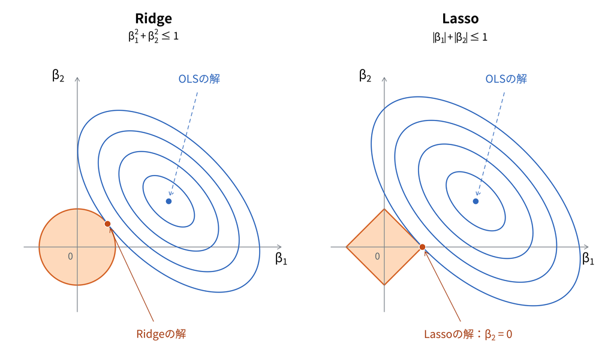

係数を縮小すると、真の関係から系統的にずれる可能性がある一方、学習データを取り直したときのばらつきを抑えられることがある。これが、正則化によって未知データの予測性能の改善を期待する理由である。強く縮小しすぎると**欠学習（underfitting）**になるため、次に正則化の強さを選ぶ方法を考える。

極端に言えば、説明変数のすべての係数が0になるほど強いペナルティを課すと、Lassoは説明変数と目的変数の関係を何も学習できなくなる。

# 3 変数処理と交差検証

RidgeとLassoを使うには、説明変数の尺度をそろえ、予測性能に基づいて $\lambda$ を選ぶ必要がある。第2回で扱った学習用・検証用データの役割を、そのまま引き継いで考える。

## 3.1 標準化が必要な理由

住宅価格を居住面積だけで予測する単回帰を考えよう。$y$ は住宅価格（万円）、$x$ は居住面積とし、計算を簡単にするため切片は0とする。

$$\hat y=\hat\beta x$$

同じ100平方メートルの住宅でも、面積をどの単位で表すかによって、係数の数値は変わる。

| 面積の単位 | $x$ | $\hat\beta$ | 予測値 $\hat y$（万円） |
| --- | --- | --- | --- |
| 1平方メートル | 100 | 30 | $30\times100=3{,}000$ |
| 100平方メートル | 1 | 3,000 | $3{,}000\times1=3{,}000$ |

予測値は同じなのに、係数は100倍違う。同じ $\lambda$ でも、Lassoのペナルティ $\lambda|\beta|$ は100倍、Ridgeのペナルティ $\lambda\beta^2/2$ は1万倍になる。つまり、単位を変えただけで、ペナルティの大きさが変わってしまう。

そこで、各説明変数から平均を引き、標準偏差で割って、**zスコア（z-score）**を計算する。この操作を標準化という。標準化後の学習用データでは、各説明変数の平均は0、標準偏差は1になる。

$$z_{ij}=\frac{x_{ij}-\bar
x_{j,\mathrm{train}}}{\sigma_{j,\mathrm{train}}}$$

平均・標準偏差は**学習用データで求め、検証用データにも同じ値を使う**。

RでRidgeやLassoを推定するには、`glmnet()` を使う。`standardize = TRUE` と指定すると、関数の内部で標準化されるため、自分で平均や標準偏差を計算する必要はない。ただし、標準化が何をしているのかは理解しておこう。

## 3.2 K-fold交差検証

データを一度だけ分けると、どのデータを学習・検証に使うかによって、結果が変わることがある。**交差検証（cross-validation）**では、検証に使う部分を入れ替えて、予測の誤差を繰り返し確かめる。一度の分け方に左右されにくく、すべてのデータを学習にも検証にも活用できる。

データを $K$ 個に分けて行う交差検証を、**K-fold交差検証**という。データを分けた各ブロックをfoldと呼ぶ。一般に $K=5$ や $K=10$ がよく使われる。今回は計算時間を短くするため、正解付きの `train.csv` 全体を使って、**5分割交差検証**で $\lambda$ を選ぶ。

train.csv（正解あり）を5つに分ける

①

②

③

④

⑤

1回目

検証

学習

学習

学習

学習

2回目

学習

検証

学習

学習

学習

3回目

学習

学習

検証

学習

学習

4回目

学習

学習

学習

検証

学習

5回目

学習

学習

学習

学習

検証

Kaggleのtest.csv

正解は非公開

最終評価用  
学習・λの選択には  
使わない

モデルを決めた後に  
予測を提出して採点

毎回、学習データの4つをまとめて一つのモデルを学習し、検証データの1つで検証する。各 $\lambda$ について5回の誤差を平均して、$\lambda$ を選ぶ。評価データの `test.csv` は、最後の評価に使う。

Kaggleでは、正解が非公開の `test.csv` があらかじめ用意されているため、今回は自分でテストデータを取り分ける必要はない。Kaggle以外のデータを自分で分割する場合は、**最初に最終評価用のテストデータを必ず取り分け、学習や $\lambda$ の選択には使わない**。残りのデータで交差検証を行う。

# 4 Rによる住宅価格の予測

## 4.1 データの準備

```r
# 初めて使うときだけ、#を外してインストールする
# install.packages(c("glmnet", "caret"))
library(glmnet)
library(caret)
```

`glmnet` は、正則化を加えた**一般化線形モデル（generalized linear model）**を推定するパッケージで、線形回帰やロジスティック回帰などに対応している。今回のRidgeとLassoも線形回帰モデルであり、係数の推定にペナルティを加える点がOLSと異なる。

Lassoでは、必要な前処理をしたうえで、データにある説明変数をすべて候補にし、交差検証で予測性能のよいモデルを選ぶこともできる。今回は、欠損値やカテゴリ変数の処理を減らすため、あらかじめ16個の数値変数を選ぶ。また、簡単にするため、築年数の計算などの特徴量エンジニアリングは行わず、同じ変数を使ってOLS・Ridge・Lassoを比較する。**Lassoによる自動選択は、この16変数の中で行う**。

```r
house_prices <- read.csv("data/house-prices/train.csv")

# 前回の数値変数を含め、16個の数値変数で比較する
data <- house_prices %>%
  select(
    SalePrice,
    GrLivArea, OverallQual, YearBuilt, LotArea,
    YearRemodAdd, TotalBsmtSF, X1stFlrSF, X2ndFlrSF,
    FullBath, HalfBath, BedroomAbvGr, TotRmsAbvGrd,
    GarageCars, GarageArea, WoodDeckSF, OpenPorchSF
  )
# 1列目の住宅価格（SalePrice）を除き、説明変数の列名を取り出す
features <- names(data)[-1]
colSums(is.na(data))
```

```
##    SalePrice    GrLivArea  OverallQual    YearBuilt      LotArea YearRemodAdd
##            0            0            0            0            0            0
##  TotalBsmtSF    X1stFlrSF    X2ndFlrSF     FullBath     HalfBath BedroomAbvGr
##            0            0            0            0            0            0
## TotRmsAbvGrd   GarageCars   GarageArea   WoodDeckSF  OpenPorchSF
##            0            0            0            0            0
```

```r
c(observations = nrow(data), predictors = length(features))
```

```
## observations   predictors
##         1460           16
```

**使用する変数の意味**

| 変数 | 内容 |
| --- | --- |
| GrLivArea | 地上居住面積（平方フィート） |
| OverallQual | 建材・仕上げの総合品質（1～10） |
| YearBuilt | 建築年 |
| LotArea | 敷地面積（平方フィート） |
| YearRemodAdd | 改修年（改修がない場合は建築年） |
| TotalBsmtSF | 地下室総面積（平方フィート） |
| X1stFlrSF | 1階面積（平方フィート） |
| X2ndFlrSF | 2階面積（平方フィート） |
| FullBath | 地上部分のフルバス数 |
| HalfBath | 地上部分のハーフバス数 |
| BedroomAbvGr | 地上部分の寝室数 |
| TotRmsAbvGrd | 地上部分の部屋数（浴室を除く） |
| GarageCars | ガレージ収容台数 |
| GarageArea | ガレージ面積（平方フィート） |
| WoodDeckSF | ウッドデッキ面積（平方フィート） |
| OpenPorchSF | 屋根のないポーチ面積（平方フィート） |

```r
# featuresに保存した16個の説明変数同士の相関を計算する
cor16 <- cor(data[features])
```

**16変数の相関係数行列**

|  | GrLivArea | OverallQual | YearBuilt | LotArea | YearRemodAdd | TotalBsmtSF | X1stFlrSF | X2ndFlrSF | FullBath | HalfBath | BedroomAbvGr | TotRmsAbvGrd | GarageCars | GarageArea | WoodDeckSF | OpenPorchSF |
| --- | --- | --- | --- | --- | --- | --- | --- | --- | --- | --- | --- | --- | --- | --- | --- | --- |
| GrLivArea | 1.00 | 0.59 | 0.20 | 0.26 | 0.29 | 0.45 | 0.57 | 0.69 | 0.63 | 0.42 | 0.52 | 0.83 | 0.47 | 0.47 | 0.25 | 0.33 |
| OverallQual | 0.59 | 1.00 | 0.57 | 0.11 | 0.55 | 0.54 | 0.48 | 0.30 | 0.55 | 0.27 | 0.10 | 0.43 | 0.60 | 0.56 | 0.24 | 0.31 |
| YearBuilt | 0.20 | 0.57 | 1.00 | 0.01 | 0.59 | 0.39 | 0.28 | 0.01 | 0.47 | 0.24 | -0.07 | 0.10 | 0.54 | 0.48 | 0.22 | 0.19 |
| LotArea | 0.26 | 0.11 | 0.01 | 1.00 | 0.01 | 0.26 | 0.30 | 0.05 | 0.13 | 0.01 | 0.12 | 0.19 | 0.15 | 0.18 | 0.17 | 0.08 |
| YearRemodAdd | 0.29 | 0.55 | 0.59 | 0.01 | 1.00 | 0.29 | 0.24 | 0.14 | 0.44 | 0.18 | -0.04 | 0.19 | 0.42 | 0.37 | 0.21 | 0.23 |
| TotalBsmtSF | 0.45 | 0.54 | 0.39 | 0.26 | 0.29 | 1.00 | 0.82 | -0.17 | 0.32 | -0.05 | 0.05 | 0.29 | 0.43 | 0.49 | 0.23 | 0.25 |
| X1stFlrSF | 0.57 | 0.48 | 0.28 | 0.30 | 0.24 | 0.82 | 1.00 | -0.20 | 0.38 | -0.12 | 0.13 | 0.41 | 0.44 | 0.49 | 0.24 | 0.21 |
| X2ndFlrSF | 0.69 | 0.30 | 0.01 | 0.05 | 0.14 | -0.17 | -0.20 | 1.00 | 0.42 | 0.61 | 0.50 | 0.62 | 0.18 | 0.14 | 0.09 | 0.21 |
| FullBath | 0.63 | 0.55 | 0.47 | 0.13 | 0.44 | 0.32 | 0.38 | 0.42 | 1.00 | 0.14 | 0.36 | 0.55 | 0.47 | 0.41 | 0.19 | 0.26 |
| HalfBath | 0.42 | 0.27 | 0.24 | 0.01 | 0.18 | -0.05 | -0.12 | 0.61 | 0.14 | 1.00 | 0.23 | 0.34 | 0.22 | 0.16 | 0.11 | 0.20 |
| BedroomAbvGr | 0.52 | 0.10 | -0.07 | 0.12 | -0.04 | 0.05 | 0.13 | 0.50 | 0.36 | 0.23 | 1.00 | 0.68 | 0.09 | 0.07 | 0.05 | 0.09 |
| TotRmsAbvGrd | 0.83 | 0.43 | 0.10 | 0.19 | 0.19 | 0.29 | 0.41 | 0.62 | 0.55 | 0.34 | 0.68 | 1.00 | 0.36 | 0.34 | 0.17 | 0.23 |
| GarageCars | 0.47 | 0.60 | 0.54 | 0.15 | 0.42 | 0.43 | 0.44 | 0.18 | 0.47 | 0.22 | 0.09 | 0.36 | 1.00 | 0.88 | 0.23 | 0.21 |
| GarageArea | 0.47 | 0.56 | 0.48 | 0.18 | 0.37 | 0.49 | 0.49 | 0.14 | 0.41 | 0.16 | 0.07 | 0.34 | 0.88 | 1.00 | 0.22 | 0.24 |
| WoodDeckSF | 0.25 | 0.24 | 0.22 | 0.17 | 0.21 | 0.23 | 0.24 | 0.09 | 0.19 | 0.11 | 0.05 | 0.17 | 0.23 | 0.22 | 1.00 | 0.06 |
| OpenPorchSF | 0.33 | 0.31 | 0.19 | 0.08 | 0.23 | 0.25 | 0.21 | 0.21 | 0.26 | 0.20 | 0.09 | 0.23 | 0.21 | 0.24 | 0.06 | 1.00 |

この16変数の中にも、相関係数が0.7以上の組がいくつも見られる。変数が増えると、一つずつ相関を確認し、どの変数を残すかを人の手で決めるのは難しくなる。特に、説明変数が1万個あるゲノム関連データでは、変数の組は約5,000万通りになり、手作業での確認は現実的ではない。

## 4.2 交差検証用のデータとfoldを準備する

データを分割する関数や方法は数多くある。これまでは `sample()` で番号をランダムに割り当てたが、交差検証も `for` 文で学習用・検証用データを順に作れば、自分で実行できる。今回は、ランダムに分けたfoldを固定し、OLS・Ridge・Lassoを同じ条件で比較するため、`caret` パッケージを使う。

`caret` は、回帰や分類のさまざまなモデルを、共通の書き方で学習・比較できるパッケージである。データの分割、交差検証、パラメータの選択をまとめて扱えるため、モデルごとに別のコードを書く手間を減らせる。

```r
# trainは、foldに分割する前のtrain.csv全体を表す
train <- data

# 説明変数の行列xと、目的変数のベクトルyを用意する
x_train <- as.matrix(train[features])
y_train <- train$SalePrice

# 三つのモデルに共通の5分割を用意する
set.seed(2026)
folds <- createFolds(y_train, k = 5, returnTrain = TRUE)
control <- trainControl(
  method = "cv", number = 5, index = folds,
  savePredictions = "final", selectionFunction = "best"
)
```

`createFolds()` で5分割を作る。`returnTrain = TRUE` は、毎回の学習に使う4つのfoldの行番号を取り出す指定である。`method = "cv"` の `cv` はcross-validation（交差検証）の略である。三つのモデルに同じ `control` を渡すことで、同じ分割で比較できる。

## 4.3 OLS・Ridge・Lassoの学習

まず、`glmnet()` でRidgeとLassoの $\lambda$ の候補を自動的に作る。**$\alpha = 0$ はRidge、$\alpha = 1$ はLassoを表す。**

次に、`train()` で三つのモデルを同じ5分割で学習・検証する。OLSには `method = "lm"`、RidgeとLassoには `method = "glmnet"` を指定する。RidgeとLassoでは、用意した候補の中から、検証での予測誤差が最も小さくなる $\lambda$ を選ぶ。

**$\lambda$の候補を準備する**

`glmnet()` は、説明変数と目的変数に応じて $\lambda$ の範囲を決め、強いペナルティから弱いペナルティへ、対数尺度で等間隔になるように候補を作る。既定では100個を予定するが、計算が途中で終了し、少なくなる場合もある。`$lambda` でその候補を取り出し、`data.frame()` で `caret` に渡す表にする。この段階では候補を用意し、次の交差検証で使う値を選ぶ。

```r
# Ridge：λの候補を自動生成する
ridge_grid <- data.frame(
  alpha = 0,
  lambda = glmnet(x_train, y_train, alpha = 0)$lambda
)

# Lasso：λの候補を自動生成する
lasso_grid <- data.frame(
  alpha = 1,
  lambda = glmnet(x_train, y_train, alpha = 1)$lambda
)
```

**三つのモデルを同じfoldで学習・検証する**

```r
# OLS：λを選ぶ必要はない
fit_ols <- train(
  x = x_train, y = y_train,
  method = "lm", trControl = control
)

# Ridge
fit_ridge <- train(
  x = x_train, y = y_train,
  method = "glmnet", trControl = control,
  tuneGrid = ridge_grid, standardize = TRUE
)

# Lasso
fit_lasso <- train(
  x = x_train, y = y_train,
  method = "glmnet", trControl = control,
  tuneGrid = lasso_grid, standardize = TRUE
)

# 選ばれたλ
rbind(Ridge = fit_ridge$bestTune, Lasso = fit_lasso$bestTune)
```

|  | alpha | lambda |
| --- | --- | --- |
| Ridge | 0 | 6281.6035 |
| Lasso | 1 | 546.3418 |

`$lambda` は自動生成された$\lambda$の候補、`tuneGrid` は交差検証で比べる候補、`$bestTune` は選ばれた値を表す。$\alpha$はRidgeでは0、Lassoでは1に固定し、$\lambda$だけを選んでいる。OLSの交差検証にも、同じ `control` を使うため、手作業で繰り返す必要はない。

$\lambda$の代表的な選び方には、次の二つがある。

| 選び方 | 意味 |
| --- | --- |
| 最小誤差の基準（min） | 平均の交差検証誤差が最小になる$\lambda$ |
| 1標準誤差ルール（1se） | 最小誤差にその標準誤差を加えた範囲内で、最も大きい$\lambda$ |

1seは、誤差が最小のモデルよりも強く正則化し、Lassoでは変数を減らせる場合がある。本講義では予測を重視し、誤差が最小になるminの方針を使う。`caret` では `selectionFunction = "best"` と指定し、各foldのRMSEの平均が最小になる$\lambda$を選ぶ。選ばれた値は `$bestTune` に保存される。

## 4.4 選んだλと係数の変化の確認

### ① 予測誤差の図：どのλを選ぶか

まず、$\lambda$ を変えると、検証用データの予測誤差がどう変わるかを確認する。学習データによく合うかではなく、学習に使わなかったデータをどれだけ正確に予測できるかで選ぶ。

次のコードで、RidgeとLassoそれぞれの検証誤差を描く。横軸は $\lambda$（対数表示）、縦軸は5つのfoldのRMSEの平均である。

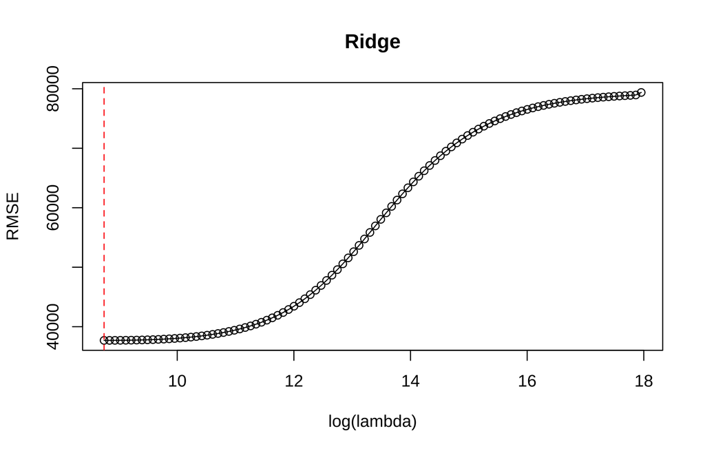

```r
# 交差検証で選ばれたλ
ridge_lambda <- fit_ridge$bestTune$lambda
lasso_lambda <- fit_lasso$bestTune$lambda

# 誤差の曲線を描き、log(λ)の位置に赤い縦線を引く
plot(RMSE ~ log(lambda), data = fit_ridge$results, type = "o", main = "Ridge")
abline(v = log(ridge_lambda), col = "red", lty = 2)
```

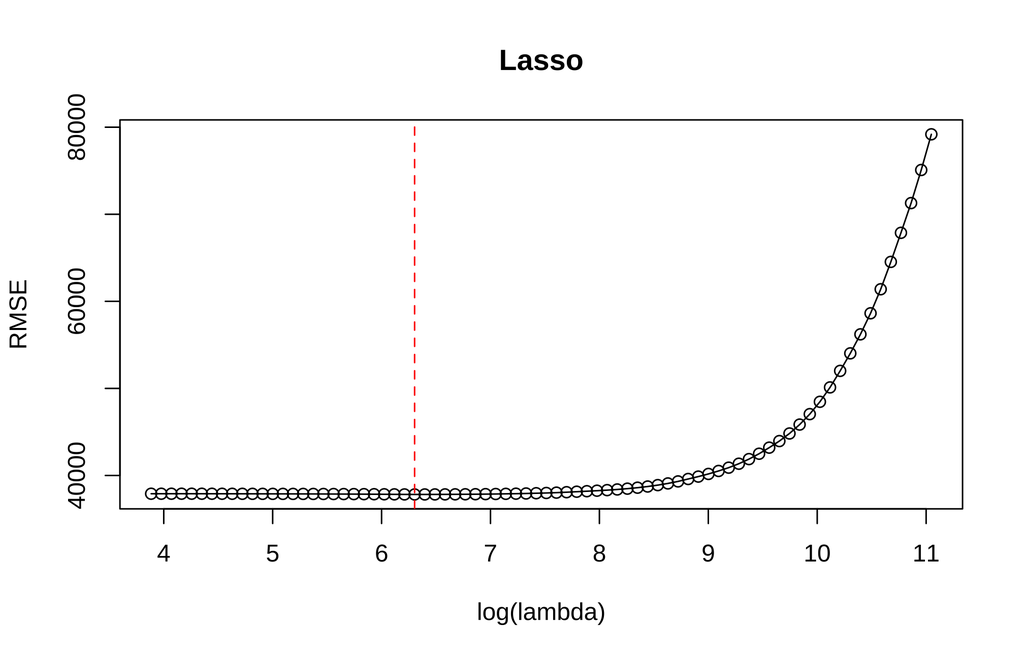

```r
plot(RMSE ~ log(lambda), data = fit_lasso$results, type = "o", main = "Lasso")
abline(v = log(lasso_lambda), col = "red", lty = 2)
```

横軸は $\lambda$ そのものではなく、自然対数 $\log(\lambda)$ である。元の値には、Rの `exp()` で戻せる。例えば、横軸が8なら、$\lambda=e^8\approx2{,}981$ となる。いくつか計算してみよう。

```r
log_lambda <- c(0, 2, 4, 6, 8, 10)
data.frame(log_lambda, lambda = exp(log_lambda))
```

| log_lambda | lambda |
| --- | --- |
| 0 | 1.000000 |
| 2 | 7.389056 |
| 4 | 54.598150 |
| 6 | 403.428793 |
| 8 | 2980.957987 |
| 10 | 22026.465795 |

### ② 係数パスの図：λを変えると係数はどう変わるか

次に、ペナルティを強めたときに、各変数の係数がどのように縮むかを確認する。この変化を描いた図を**係数パス**という。横軸は $\lambda$（対数表示）、縦軸は回帰係数で、1本の線が一つの説明変数を表す。Ridge、Lassoの順に、それぞれの図を描く。

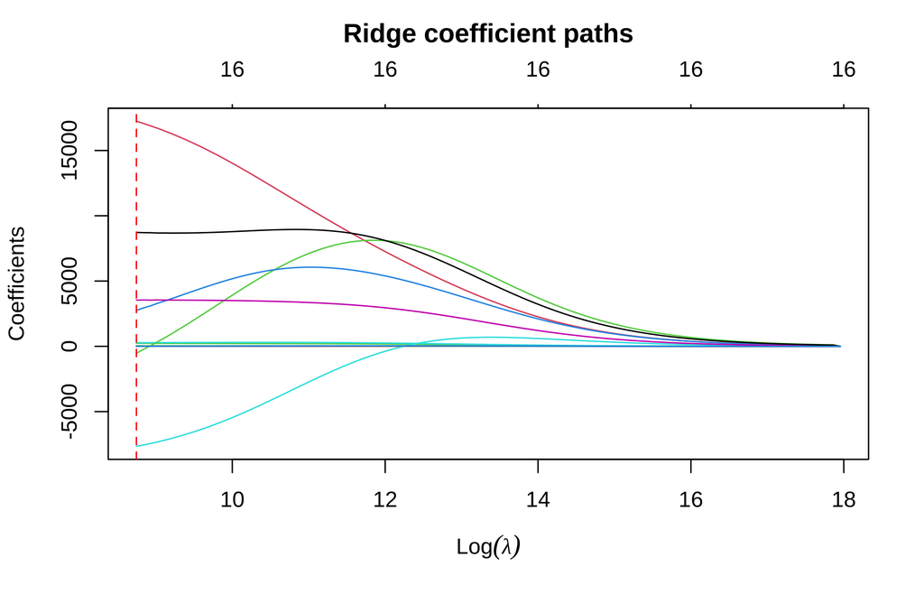

```r
plot(fit_ridge$finalModel, xvar = "lambda", sign.lambda = 1)
abline(v = log(ridge_lambda), col = "red", lty = 2)
title("Ridge coefficient paths", line = 2.5)
```

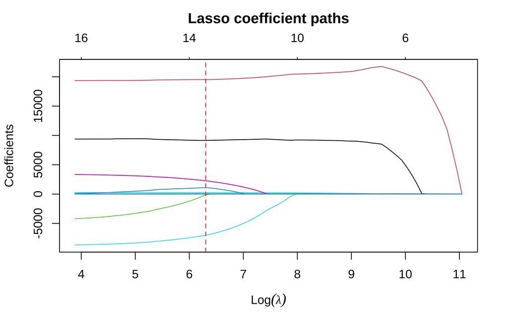

```r
plot(fit_lasso$finalModel, xvar = "lambda", sign.lambda = 1)
abline(v = log(lasso_lambda), col = "red", lty = 2)
title("Lasso coefficient paths", line = 2.5)
```

右ほどペナルティが強くなる。Ridgeは係数を縮め、Lassoは一部を0にして変数を予測式から外す。図の係数は元の単位に戻されているため、線の高さをそのまま重要度として比較しない。

## 4.5 交差検証で予測誤差を比較する

選ばれたパラメータでの各foldの検証結果が、`fit_ols$pred`、`fit_ridge$pred`、`fit_lasso$pred` に保存される。以下の `metrics()` に、これらのモデルオブジェクトを一つずつ渡す。例えば `metrics(fit_ridge)` とすると、関数内の `model` は `fit_ridge` を表す。`p <- model$pred` で検証結果の表を取り出し、実際の価格の列 `p$obs` と予測値の列 `p$pred` からRMSE・MAEを計算する。

```r
# 検証用データの実際の価格と予測値から、RMSE・MAEを求める
metrics <- function(model) {
  p <- model$pred  # 検証結果の表を取り出す
  # p$obs：実際の価格、p$pred：検証用の予測値
  c(RMSE = sqrt(mean((p$obs - p$pred)^2)),
    MAE = mean(abs(p$obs - p$pred)))
}

# 三つのモデルの誤差を計算し、rbind()で一つの表にまとめる
comparison <- rbind(
  OLS = metrics(fit_ols),
  Ridge = metrics(fit_ridge),
  Lasso = metrics(fit_lasso)
)
knitr::kable(comparison, digits = 0)
```

|  | RMSE | MAE |
| --- | --- | --- |
| OLS | 38347 | 23183 |
| Ridge | 38055 | 22959 |
| Lasso | 38203 | 23169 |

この表はモデルを選ぶための検証結果であり、最終評価ではない。最後に、Kaggleの `test.csv` を予測して提出する。

## 4.6 OLS・Ridge・Lassoの係数を比較する

機械学習では、予測性能に注目し、係数の推定値など、モデルの内部を確かめずに使うこともある。そのため、処理の中身を意識しない**ブラックボックス**として扱われることがある。ここではRidgeとLassoの係数を確認し、多重共線性や高次元データに対して、正則化がどのように働くかを考えよう。

`finalModel` は、全学習データで推定したモデルを表す。OLSと、交差検証で選んだ $\lambda$ でのRidge・Lassoの係数を並べて比較する。

```r
# OLSと、選ばれたλでのRidge・Lassoの係数を取り出す
b_ols <- coef(fit_ols$finalModel)
b_ridge <- as.matrix(coef(fit_ridge$finalModel, s = ridge_lambda))
b_lasso <- as.matrix(coef(fit_lasso$finalModel, s = lasso_lambda))

# 同じ変数の係数を横に並べる
coef_table <- data.frame(
  Variable = names(b_ols),
  OLS = b_ols,
  Ridge = b_ridge[, 1],
  Lasso = b_lasso[, 1],
  row.names = NULL
)
knitr::kable(coef_table, digits = 2)
```

| Variable | OLS | Ridge | Lasso |
| --- | --- | --- | --- |
| (Intercept) | -1066578.41 | -1062333.46 | -968866.40 |
| GrLivArea | 14.00 | 25.49 | 45.61 |
| OverallQual | 19339.06 | 17240.70 | 19521.70 |
| YearBuilt | 255.67 | 230.38 | 222.29 |
| LotArea | 0.60 | 0.56 | 0.56 |
| YearRemodAdd | 252.29 | 277.84 | 234.97 |
| TotalBsmtSF | 19.01 | 20.88 | 19.10 |
| X1stFlrSF | 42.70 | 26.15 | 9.14 |
| X2ndFlrSF | 35.00 | 17.39 | 0.00 |
| FullBath | -4621.09 | -530.00 | -114.86 |
| HalfBath | -78.04 | 2745.96 | 1113.34 |
| BedroomAbvGr | -8862.00 | -7662.25 | -7041.48 |
| TotRmsAbvGrd | 3479.60 | 3535.62 | 2261.65 |
| GarageCars | 9296.40 | 8725.27 | 9153.52 |
| GarageArea | 11.92 | 19.05 | 13.39 |
| WoodDeckSF | 33.72 | 34.48 | 32.11 |
| OpenPorchSF | 3.08 | 9.02 | 0.00 |

```r
# 切片を除き、厳密に0でない係数の数を数える
sum(b_lasso[-1, 1] != 0)
```

```
## [1] 14
```

## 4.7 演習：Kaggleに提出して比較する

今回学習したOLS・Ridge・Lassoを使い、次の手順を自分で試してみよう。

1. 各モデルで `test.csv` の住宅価格を予測する。
2. `Id` と予測した `SalePrice` を、モデルごとに別のCSVファイルに保存する。
3. 三つのファイルをそれぞれKaggleに提出し、スコアを比較する。前回のモデルより改善したか、RidgeやLassoはOLSより良い結果になったかを確認しよう。

予測・CSVの保存・提出の具体的な手順は、前回の講義資料を参照する。`test.csv` の今回使う変数には欠損値があるため、予測前に `train.csv` の各変数の中央値で補完する。

Kaggleのスコアは小さいほどよい。価格の対数で評価するため、授業内で計算した米ドル単位のRMSEとは数値を直接比較しない。